# Practical machine learning project

# Key ojective

This repo is created as the final report for the course project for “Practical Machine Learning” course offered by Coursera. The main goal of the project is to predict the manner in which 6 participants performed some exercise as described below. This is the “classe” variable in the training set. The machine learning algorithm described below is applied to the 20 test cases available in the test data and the predictions are submitted in appropriate format to the Course Project Prediction Quiz for automated grading.

I have attached the code (in R) as a separate file and all the visualizations are attached separately as well.

# Data Loading

The training data for this project are available here: https://d396qusza40orc.cloudfront.net/predmachlearn/pml-training.csv The test data are available here: https://d396qusza40orc.cloudfront.net/predmachlearn/pml-testing.csv

Description of the datasets content from the authors’ website:

“Six young health participants were asked to perform one set of 10 repetitions of the Unilateral Dumbbell Biceps Curl in five different fashions: exactly according to the specification (Class A), throwing the elbows to the front (Class B), lifting the dumbbell only halfway (Class C), lowering the dumbbell only halfway (Class D) and throwing the hips to the front (Class E). Class A corresponds to the specified execution of the exercise, while the other 4 classes correspond to common mistakes. Participants were supervised by an experienced weight lifter to make sure the execution complied to the manner they were supposed to simulate. The exercises were performed by six male participants aged between 20-28 years, with little weight lifting experience. We made sure that all participants could easily simulate the mistakes in a safe and controlled manner by using a relatively light dumbbell (1.25kg).”

I have retained 70% data for traing and 30% for validation.

```r
library(knitr)

library(caret)

library(rpart)

library(rpart.plot)

library(rattle)

library(randomForest)

library(corrplot)

set.seed(42)

##################### downloading train and test data

UrlTrain <- "http://d396qusza40orc.cloudfront.net/predmachlearn/pml-training.csv" # setting the url for training data

UrlTest <- "http://d396qusza40orc.cloudfront.net/predmachlearn/pml-testing.csv" # setting the url for test data

training <- read.csv(url(UrlTrain)) # downlaoding training data

testing <- read.csv(url(UrlTest)) # downlaoding test data

#################### creating data partitions for validation (split 70 / 30)

inTrain <- createDataPartition(training$classe, p=0.7, list=FALSE)

TrainSet <- training[inTrain, ] # training set

TestSet <- training[-inTrain, ] # validation set

dim(TrainSet)
```

```
## [1] 13737   160
```

```r
dim(TestSet)
```

```
## [1] 5885  160
```

# Data Cleaning

I have performed three key steps for data cleaning 1. Removing independent variables that had near zero variance as they will not really contribute in explaining the variance of dependent variable 2. Removing variables that were mainly NAs

3. Variables that were purely for identification (metadata for records)

## Data cleaning section 1:

```r
NZV <- nearZeroVar(TrainSet) # removing variable with near zero variance

TrainSet <- TrainSet[, -NZV]

TestSet <- TestSet[, -NZV]

dim(TrainSet)
```

```
## [1] 13737   104
```

```r
dim(TestSet)
```

```
## [1] 5885  104
```

## data cleaning section 2:

```r
AllNA <- sapply(TrainSet, function(x) mean(is.na(x))) > 0.95 # removing variables and are mostly NAs

TrainSet <- TrainSet[, AllNA==FALSE]

TestSet <- TestSet[, AllNA==FALSE]

dim(TrainSet)
```

```
## [1] 13737    59
```

```r
dim(TestSet)
```

```
## [1] 5885   59
```

## data cleaning section 3:

```r
TrainSet <- TrainSet[, -(1:5)] # removing the identification only variables in column 1 to 5

TestSet <- TestSet[, -(1:5)]

dim(TrainSet)
```

```
## [1] 13737    54
```

```r
dim(TestSet)
```

```
## [1] 5885   54
```

# Correlation analysis

Correlation analysis is key to understand if dimensionality reduction is needed for the data. Inthe present case I have not applier PCA

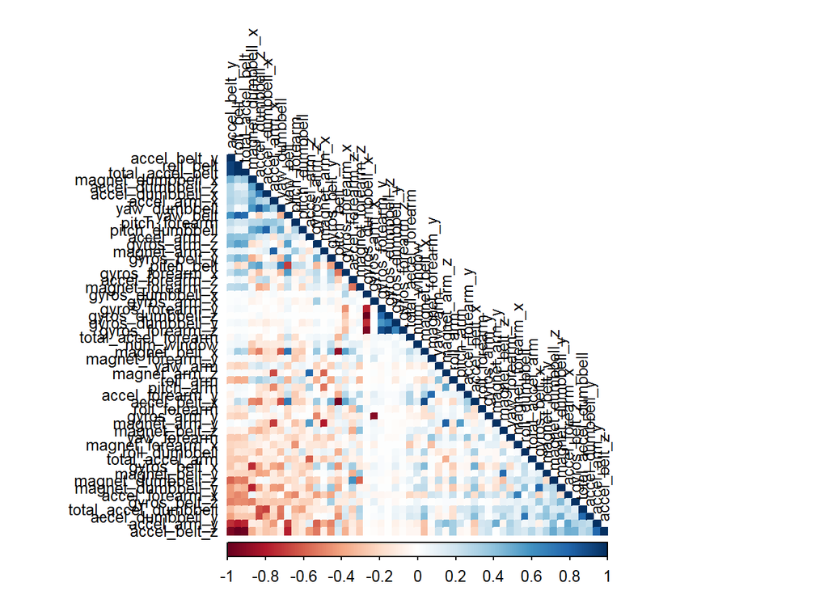

# Model building

I built RandonForest, Decision Tree and GBM based model for prediction. Random forest performed the best. (for accuracy and confusion matrix please see the visualizations)

## Random Forest

```r
set.seed(42)

controlRF <- trainControl(method="cv", number=3, verboseIter=FALSE)

modFitRandForest <- train(classe ~ ., data=TrainSet, method="rf", trControl=controlRF) # building model on the training data

modFitRandForest$finalModel
```

```
##
## Call:
##  randomForest(x = x, y = y, mtry = param$mtry)
##                Type of random forest: classification
##                      Number of trees: 500
## No. of variables tried at each split: 27
##
##         OOB estimate of  error rate: 0.28%
## Confusion matrix:
##      A    B    C    D    E  class.error
## A 3905    0    0    0    1 0.0002560164
## B   11 2644    2    1    0 0.0052671181
## C    0    6 2390    0    0 0.0025041736
## D    0    0   13 2238    1 0.0062166963
## E    0    0    0    4 2521 0.0015841584
```

```r
predictRandForest <- predict(modFitRandForest, newdata=TestSet) # getting predictions on the validation data

confMatRandForest <- confusionMatrix(predictRandForest, TestSet$classe)

confMatRandForest
```

```
## Confusion Matrix and Statistics
##
##           Reference
## Prediction    A    B    C    D    E
##          A 1673    2    0    0    0
##          B    1 1137    4    0    0
##          C    0    0 1022    2    0
##          D    0    0    0  962    0
##          E    0    0    0    0 1082
##
## Overall Statistics
##
##                Accuracy : 0.9985
##                  95% CI : (0.9971, 0.9993)
##     No Information Rate : 0.2845
##     P-Value [Acc > NIR] : < 2.2e-16
##
##                   Kappa : 0.9981
##  Mcnemar's Test P-Value : NA
##
## Statistics by Class:
##
##                      Class: A Class: B Class: C Class: D Class: E
## Sensitivity            0.9994   0.9982   0.9961   0.9979   1.0000
## Specificity            0.9995   0.9989   0.9996   1.0000   1.0000
## Pos Pred Value         0.9988   0.9956   0.9980   1.0000   1.0000
## Neg Pred Value         0.9998   0.9996   0.9992   0.9996   1.0000
## Prevalence             0.2845   0.1935   0.1743   0.1638   0.1839
## Detection Rate         0.2843   0.1932   0.1737   0.1635   0.1839
## Detection Prevalence   0.2846   0.1941   0.1740   0.1635   0.1839
## Balanced Accuracy      0.9995   0.9986   0.9978   0.9990   1.0000
```

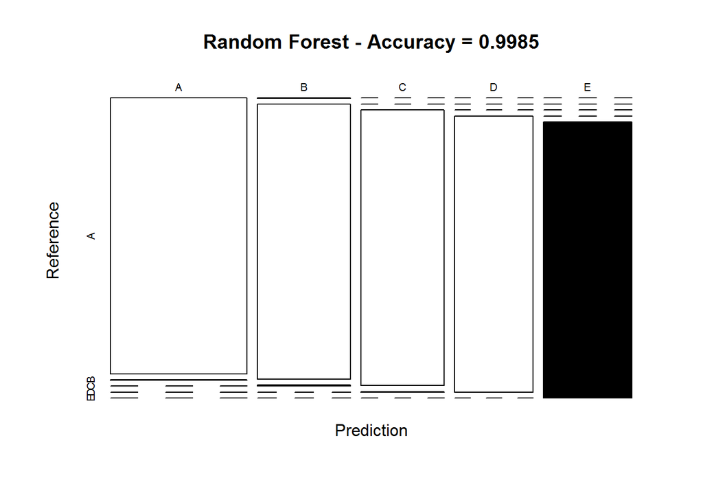

## Decision Tree Model

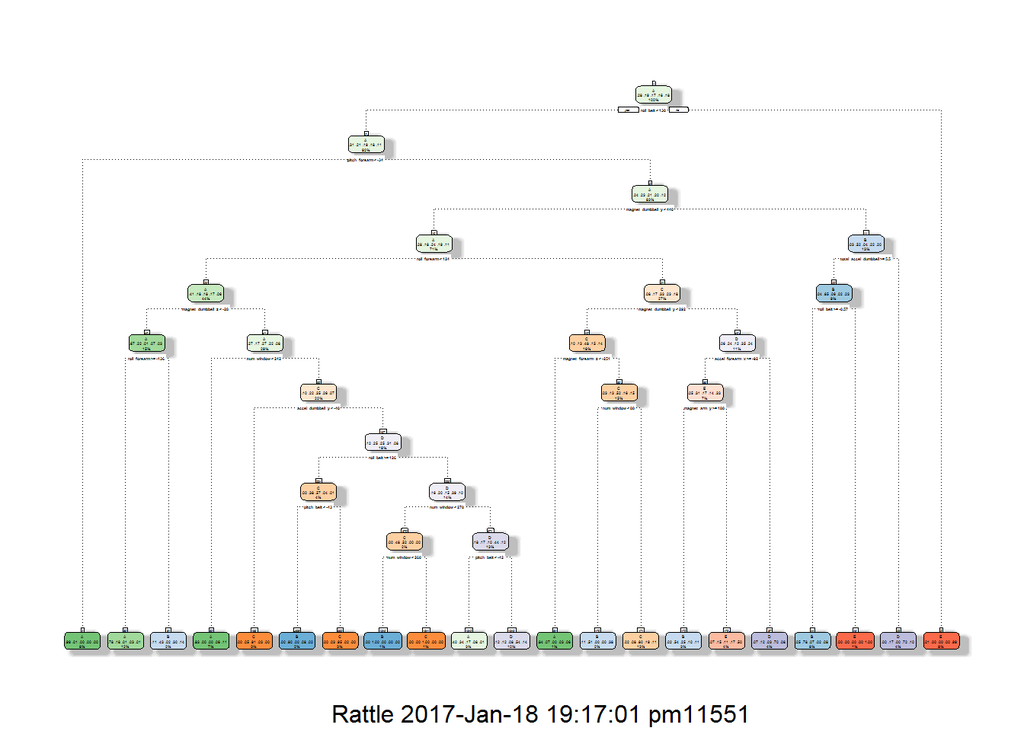

```r
set.seed(42)

modFitDecTree <- rpart(classe ~ ., data=TrainSet, method="class") # building model on the training data

fancyRpartPlot(modFitDecTree)
```

```r
predictDecTree <- predict(modFitDecTree, newdata=TestSet, type="class") # getting predictions on the validation data

confMatDecTree <- confusionMatrix(predictDecTree, TestSet$classe)

confMatDecTree
```

```
## Confusion Matrix and Statistics
##
##           Reference
## Prediction    A    B    C    D    E
##          A 1474  195   44   62   53
##          B   53  692   61   89  117
##          C   19   66  830  122   94
##          D  102  153   62  650  138
##          E   26   33   29   41  680
##
## Overall Statistics
##
##                Accuracy : 0.7351
##                  95% CI : (0.7236, 0.7463)
##     No Information Rate : 0.2845
##     P-Value [Acc > NIR] : < 2.2e-16
##
##                   Kappa : 0.6642
##  Mcnemar's Test P-Value : < 2.2e-16
##
## Statistics by Class:
##
##                      Class: A Class: B Class: C Class: D Class: E
## Sensitivity            0.8805   0.6076   0.8090   0.6743   0.6285
## Specificity            0.9159   0.9326   0.9381   0.9075   0.9731
## Pos Pred Value         0.8063   0.6838   0.7339   0.5882   0.8405
## Neg Pred Value         0.9507   0.9083   0.9588   0.9343   0.9208
## Prevalence             0.2845   0.1935   0.1743   0.1638   0.1839
## Detection Rate         0.2505   0.1176   0.1410   0.1105   0.1155
## Detection Prevalence   0.3106   0.1720   0.1922   0.1878   0.1375
## Balanced Accuracy      0.8982   0.7701   0.8735   0.7909   0.8008
```

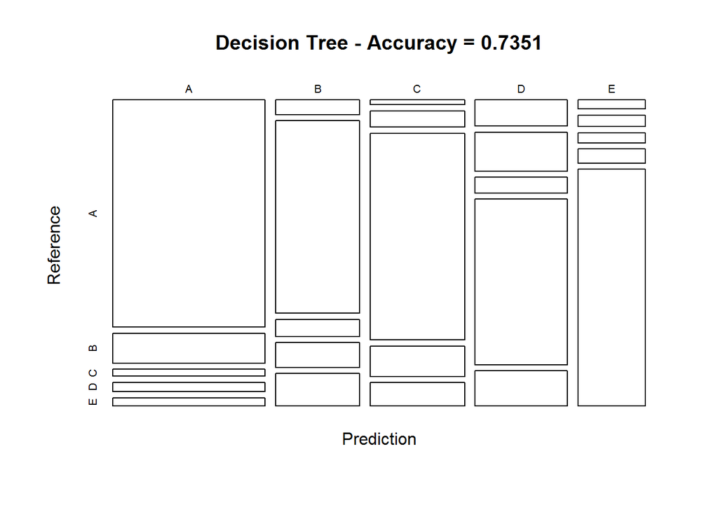

## GBM Model

```r
set.seed(42)

controlGBM <- trainControl(method = "repeatedcv", number = 5, repeats = 1)

modFitGBM <- train(classe ~ ., data=TrainSet, method = "gbm", trControl = controlGBM, verbose = FALSE) # building model on the training data
modFitGBM$finalModel
```

```
## A gradient boosted model with multinomial loss function.
## 150 iterations were performed.
## There were 53 predictors of which 43 had non-zero influence.
```

```r
predictGBM <- predict(modFitGBM, newdata=TestSet) # getting predictions on the validation data

confMatGBM <- confusionMatrix(predictGBM, TestSet$classe)

confMatGBM
```

```
## Confusion Matrix and Statistics
##
##           Reference
## Prediction    A    B    C    D    E
##          A 1673   14    0    1    0
##          B    1 1120    3    3    7
##          C    0    2 1016   14    2
##          D    0    3    6  946   13
##          E    0    0    1    0 1060
##
## Overall Statistics
##
##                Accuracy : 0.9881
##                  95% CI : (0.985, 0.9907)
##     No Information Rate : 0.2845
##     P-Value [Acc > NIR] : < 2.2e-16
##
##                   Kappa : 0.985
##  Mcnemar's Test P-Value : NA
##
## Statistics by Class:
##
##                      Class: A Class: B Class: C Class: D Class: E
## Sensitivity            0.9994   0.9833   0.9903   0.9813   0.9797
## Specificity            0.9964   0.9971   0.9963   0.9955   0.9998
## Pos Pred Value         0.9911   0.9877   0.9826   0.9773   0.9991
## Neg Pred Value         0.9998   0.9960   0.9979   0.9963   0.9954
## Prevalence             0.2845   0.1935   0.1743   0.1638   0.1839
## Detection Rate         0.2843   0.1903   0.1726   0.1607   0.1801
## Detection Prevalence   0.2868   0.1927   0.1757   0.1645   0.1803
## Balanced Accuracy      0.9979   0.9902   0.9933   0.9884   0.9897
```

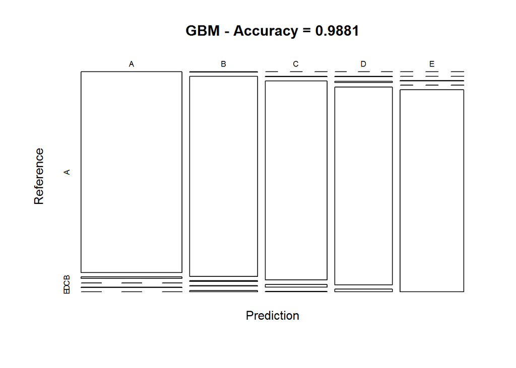

# Prediction on the test data

```r
predictTEST <- predict(modFitRandForest, newdata=testing)

predictTEST
```

```
##  [1] B A B A A E D B A A B C B A E E A B B B
## Levels: A B C D E
```